# Olympic Data

# 1 Introduction

Team 010100 are the following members: Izzy Illari, Lucia Illari, Omar Qusous, and Lydia Teinfalt. You may find our work over on [GitHub](https://github.com/IzzyIllari/DATS-Model-Proj).

For the second portion of our group project, we kept Olympics data from the EDA. Our SMART questions were `What factors can be used to model the probability of being awarded a medal?` What groups/clusters do athletes of different sports fall into? How does a pandemic affect the medals awarded? How can the evolution of athlete characteristics over time be modelled? With these questions in mind we went to see if we could find use the data on Olympians to find patterns and create models that could answer the questions.

We used a dataset called `120 years of Olympic history: athletes and results` on Kaggle over here: https://www.kaggle.com/heesoo37/120-years-of-olympic-history-athletes-and-results. This historical dataset includes all Olympic Games from Athens 1896 to Rio 2016, which was scraped from https://www.sports-reference.com/. We focused on data from Olympic events 1960-2016 when looking at clustering, Kmeans, Linear and Logit Regression and trends over time. For the pandemic analysis, we focused on data of Olympics participating in events before and after the H1N1 Pandemic from 1918-1919.

The report is organized as follows:

1. Summary of Dataset
2. Data Prep
3. EDA
4. Clustering, Kmeans, Kmedoids
5. Linear and Logit Regression
6. Random Forest
7. Pandemic (Spanish Flu)
8. Trends over time
9. Summary and Conclusion
10. References

# 2 Summary of Dataset

The data looks like the following:

```
'data.frame':   151977 obs. of  24 variables:
 $ NOC         : Factor w/ 122 levels "AFG","ALB","AND",..: 1 1 1 1 1 1 1 1 1 1 ...
 $ Year        : int  1960 1960 1960 1960 1960 1960 1960 1960 1960 1960 ...
 $ Decade      : Factor w/ 6 levels "1960s","1970s",..: 1 1 1 1 1 1 1 1 1 1 ...
 $ ID          : Factor w/ 74771 levels "1","2","6","7",..: 32644 32479 60453 32515 70738 16344 21919 59125 70738 32153 ...
 $ First.Name  : Factor w/ 14118 levels "","A","A.","Aadam",..: 8716 3731 64 599 64 11978 64 4634 64 8716 ...
 $ Name        : Factor w/ 74268 levels "  Gabrielle Marie \"Gabby\" Adcock (White-)",..: 48941 19066 219 3341 221 64833 216 23793 221 48946 ...
 $ Last.Name   : Factor w/ 47370 levels "","-)","-Alard)",..: 23228 23112 38893 23137 44908 13260 16633 37860 44908 22890 ...
 $ Sex         : Factor w/ 2 levels "F","M": 2 2 2 2 2 2 2 2 2 2 ...
 $ Age         : int  24 18 20 35 20 28 22 23 20 20 ...
 $ Height      : int  171 162 178 166 179 168 172 170 179 166 ...
 $ Weight      : num  78 52 68 66 75 73 70 58 75 62 ...
 $ BMI         : num  26.7 19.8 21.5 24 23.4 ...
 $ BMI.Category: Factor w/ 5 levels "0","1","2","3",..: 4 1 3 3 3 4 3 3 3 3 ...
 $ Team        : Factor w/ 332 levels "Acipactli","Afghanistan",..: 2 2 2 2 2 2 2 2 2 2 ...
 $ Population  : int  8996973 8996973 8996973 8996973 8996973 8996973 8996973 8996973 8996973 8996973 ...
 $ GDP         : num  5.38e+08 5.38e+08 5.38e+08 5.38e+08 5.38e+08 ...
 $ GDPpC       : num  59.8 59.8 59.8 59.8 59.8 ...
 $ Games       : Factor w/ 30 levels "1960 Summer",..: 1 1 1 1 1 1 1 1 1 1 ...
 $ Season      : Factor w/ 2 levels "Summer","Winter": 1 1 1 1 1 1 1 1 1 1 ...
 $ City        : Factor w/ 29 levels "Albertville",..: 19 19 19 19 19 19 19 19 19 19 ...
 $ Sport       : Factor w/ 51 levels "Alpine Skiing",..: 51 51 3 51 3 51 3 3 3 51 ...
 $ Event       : Factor w/ 489 levels "Alpine Skiing Men's Combined",..: 478 468 17 476 33 482 22 24 18 466 ...
 $ Medal       : Factor w/ 4 levels "Bronze","Gold",..: 3 3 3 3 3 3 3 3 3 3 ...
 $ Medal.No.Yes: Factor w/ 2 levels "0","1": 1 1 1 1 1 1 1 1 1 1 ...
```

The athlete events data has 24 columns and 151977 rows/entries, for a total of 3647448 individual data points. In `olympic_data` each row corresponds to an individual athlete competing in an individual Olympic event. The variables are the following:

1. ID: Unique number for each athlete
2. Name: Athlete’s name
3. Sex: M or F
4. Age: Integer
5. Height: centimeters
6. Weight: kilograms
7. Team: Team name
8. NOC: National Olympic Committee 3-letter code
9. Games: Year and season
10. Year: Integer
11. Season: Summer or Winter
12. City: Host city
13. Sport
14. Event
15. Medal: Gold, Silver, Bronze, or NA

To prepare our data for EDA we dropped the Olympic event: Art Sculpting. NAs were also removed. We have modified the data from the kaggle dataset from which it was originally taken. The dataset now starts at 1960 and includes the new following variables:

1. Decade (factor)
2. First name (factor)
3. Last name (factor)
4. BMI (numeric)
5. BMI category (factor)
6. Population (numeric)
7. GDP (numeric)
8. GDPpC (numeric)
9. Medal: Yes or No (factor)

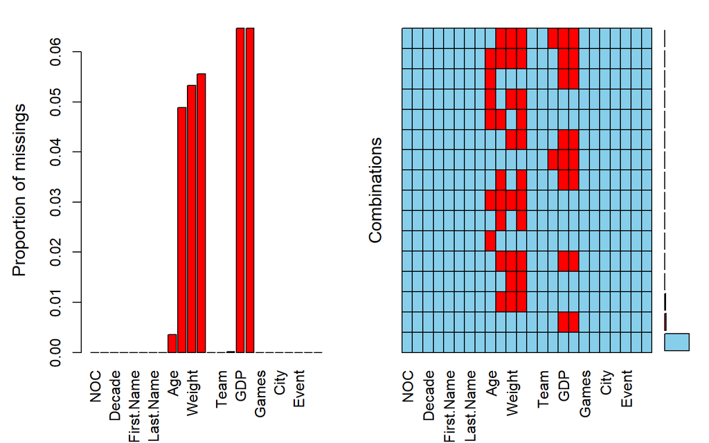

# 3 EDA

For EDA, we can do a quick summary to just look at the data.

Table: Statistics summary.

|  | NOC | Year | Decade | ID | First.Name | Name | Last.Name | Sex | Age | Height | Weight | BMI | BMI.Category | Team | Population | GDP | GDPpC | Games | Season | City | Sport | Event | Medal | Medal.No.Yes |
| --- | --- | --- | --- | --- | --- | --- | --- | --- | --- | --- | --- | --- | --- | --- | --- | --- | --- | --- | --- | --- | --- | --- | --- | --- |
| Min | USA :12218 | 1960 | 1960s:14506 | 94406 : 30 | John : 1102 | Michael Fred Phelps, II: 30 | Jr. : 488 | F:46954 | 12.00 | 127.0 | 28.00 | 10.50 | 0:16785 | United States:11748 | 9.891e+03 | 3.029e+07 | 59.5 | 2000 Summer:10621 | Summer:105729 | Sydney :10621 | Athletics :18072 | Ice Hockey Men’s Ice Hockey : 2399 | Bronze : 6116 | 0:115990 |
| Q1 | CAN : 7527 | 1984 | 1970s:11261 | 11951 : 27 | David : 995 | Ole Einar Bjrndalen : 27 | Smith : 269 | M:87011 | 21.00 | 168.0 | 60.00 | 20.90 | 1: 3311 | Canada : 7250 | 1.028e+07 | 6.500e+10 | 2759.0 | 2008 Summer:10568 | Winter: 28236 | Beijing :10568 | Swimming :12767 | Hockey Men’s Hockey : 2024 | Gold : 5941 | 1: 17975 |
| Median | ITA : 7419 | 1998 | 1980s:19330 | 91845 : 25 | Michael: 923 | Yang Wei : 26 | Garca : 256 | NA | 24.00 | 175.0 | 70.00 | 22.50 | 2:92817 | France : 7201 | 4.208e+07 | 3.300e+11 | 10586.0 | 2016 Summer:10448 | NA | Rio de Janeiro:10448 | Gymnastics :10437 | Football Men’s Football : 1996 | No Medal:115990 | NA |
| Mean | FRA : 7358 | 1995 | 1990s:23126 | 12678 : 24 | Kim : 882 | Gabriella Paruzzi : 25 | Silva : 249 | NA | 25.14 | 175.3 | 70.47 | 22.73 | 3:18254 | Italy : 7174 | 1.132e+08 | 1.490e+12 | 16809.3 | 2004 Summer:10120 | NA | Athina :10120 | Cross Country Skiing: 5434 | Basketball Men’s Basketball : 1469 | Silver : 5918 | NA |
| Q3 | JPN : 7219 | 2008 | 2000s:38099 | 14170 : 24 | Robert : 808 | Lee Ju-Hyeong : 25 | Rodrguez: 219 | NA | 28.00 | 183.0 | 79.00 | 24.20 | 4: 2798 | Japan : 7071 | 9.315e+07 | 1.340e+12 | 26401.8 | 2012 Summer: 9904 | NA | London : 9904 | Cycling : 5044 | Cycling Men’s Road Race, Individual: 1306 | NA | NA |
| Max | GBR : 7169 | 2016 | 2010s:27643 | 15991 : 24 | Jos : 760 | Alberto Busnari : 24 | Gonzlez : 217 | NA | 71.00 | 226.0 | 214.00 | 63.90 | NA | Great Britain: 6915 | 1.380e+09 | 1.870e+13 | 178846.0 | 1996 Summer: 9102 | NA | Atlanta : 9102 | Rowing : 4712 | Water Polo Men’s Water Polo : 1286 | NA | NA |
| NA | (Other):85055 | NA | NA | (Other):133811 | (Other):128495 | (Other) :133808 | (Other) :132267 | NA | NA | NA | NA | NA | NA | (Other) :86606 | NA | NA | NA | (Other) :73202 | NA | (Other) :73202 | (Other) :77499 | (Other) :123485 | NA | NA |

# 4 Olympics Correlation plot

Just quickly visualizing thw correlation will be useful for model building, but we have to be mindful of the fact that columns such as Medal and Medal.No.Yes are noturally going to be highly correlated.

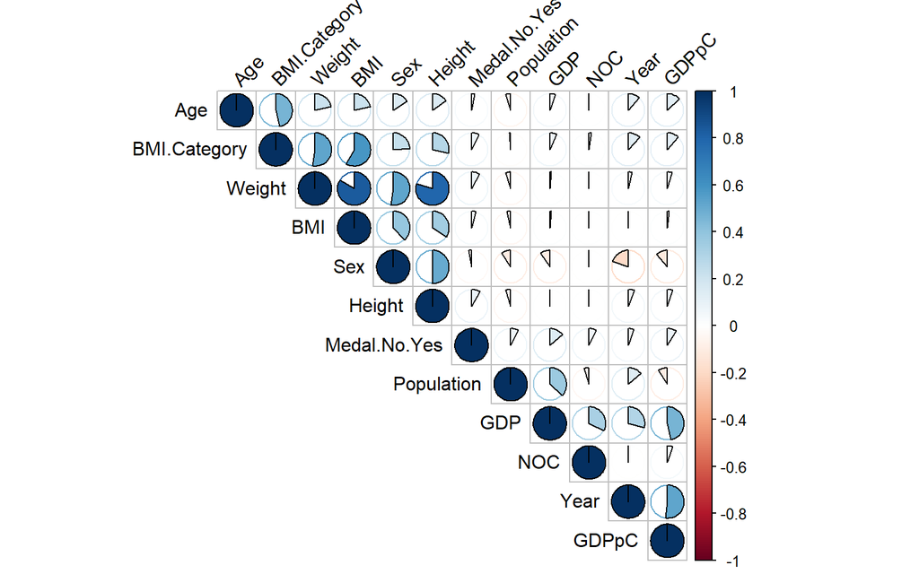

It might be more useful to focus in on the correlations for only the variable Medal.No.Yes and Medal:

| rowname | Medal.No.Yes |
| --- | --- |
| GDP | 0.1414144 |
| GDPpC | 0.0884261 |
| Height | 0.0831910 |
| Weight | 0.0771523 |
| Population | 0.0756385 |
| BMI.Category | 0.0722161 |
| NOC | 0.0663156 |
| Team | 0.0620423 |
| Event | 0.0551700 |
| Sport | 0.0550994 |
| Year | 0.0520386 |
| Decade | 0.0517238 |
| Games | 0.0513962 |
| BMI | 0.0418939 |
| Age | 0.0314189 |
| ID | 0.0105085 |
| First.Name | 0.0044511 |
| Name | 0.0042080 |
| Last.Name | -0.0067437 |
| City | -0.0180115 |
| Sex | -0.0305938 |
| Season | -0.0420744 |
| Medal | -0.4586621 |

| rowname | Medal |
| --- | --- |
| Season | 0.0237157 |
| City | 0.0108140 |
| Sex | 0.0083743 |
| Last.Name | 0.0032221 |
| Name | -0.0017224 |
| First.Name | -0.0017838 |
| ID | -0.0057542 |
| Age | -0.0150506 |
| Games | -0.0204830 |
| Decade | -0.0208330 |
| Year | -0.0209759 |
| Team | -0.0211824 |
| BMI | -0.0230238 |
| Event | -0.0268180 |
| Sport | -0.0271357 |
| Population | -0.0276393 |
| NOC | -0.0294776 |
| BMI.Category | -0.0364803 |
| GDPpC | -0.0372752 |
| Weight | -0.0380738 |
| Height | -0.0381812 |
| GDP | -0.0600564 |
| Medal.No.Yes | -0.4586621 |

Unless you ignore the athletes that didn’t receive a medal, building a general model from the variable Medal.No.Yes might be a better idea, based off the strength of the correlations.